# Exploring Knitr

## Figures

We should also create a nice figure for this analysis. This is pretty easy in R. I build plots interactively, getting the basic ideas done first, then adding complexity. Lets start with the code below.

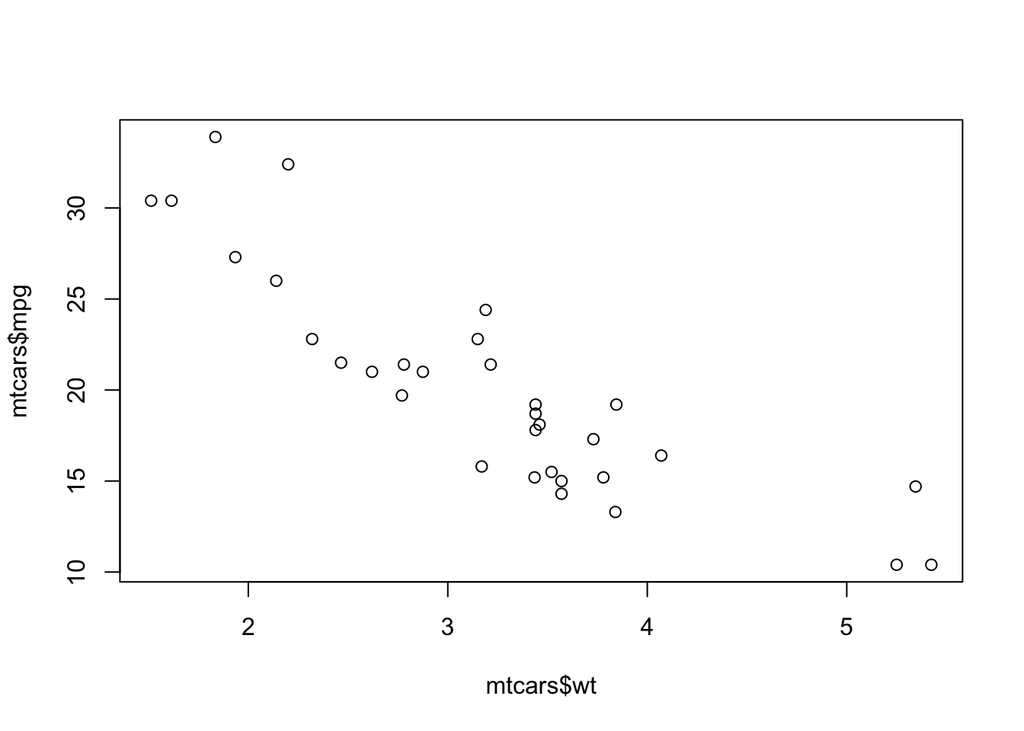

```r
  plot(mtcars$wt, mtcars$mpg)
```

We can do much much better. Lets add a title and axis labels.

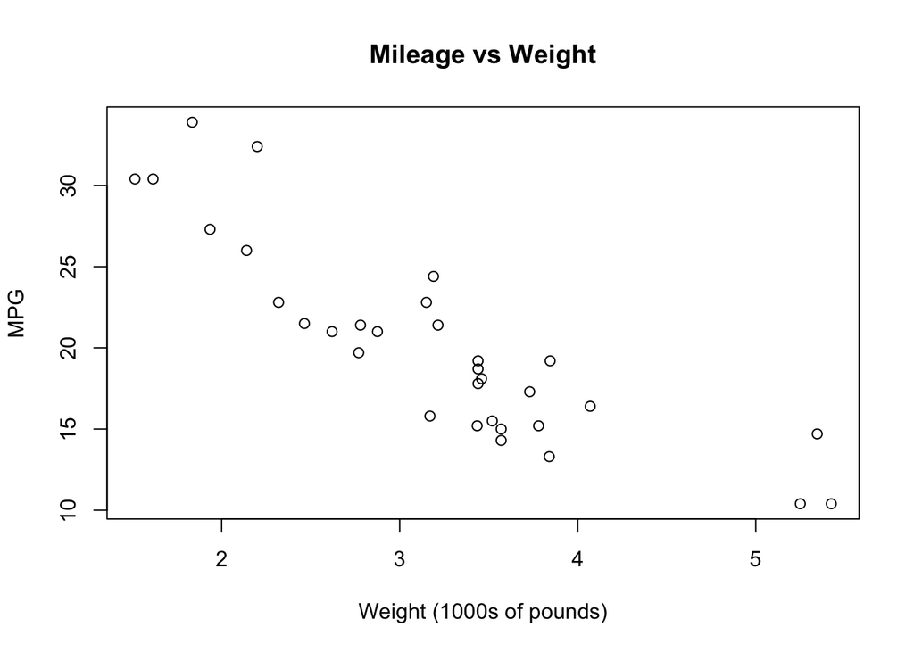

```r
    plot(mtcars$wt, mtcars$mpg, main = "Mileage vs Weight", xlab = "Weight (1000s of pounds)", ylab = "MPG")
```

We can also add a regression line.

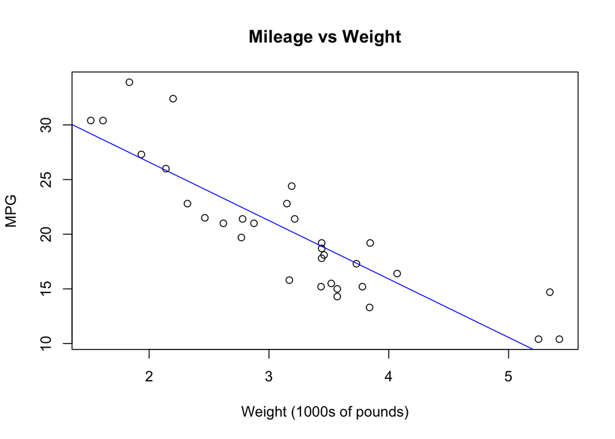

```r
plot(mtcars$wt, mtcars$mpg, main = "Mileage vs Weight", xlab = "Weight (1000s of pounds)", ylab = "MPG")
  abline(mtcars.regression1, col="blue")
```

We might also like to add another plot so that they are side by side. The the initial plot may not be side by side. Adjust the plot width in the code chunk options until they are side by side. Also, in most publications we wouldn’t want to show the code. Here we turn echo to false.

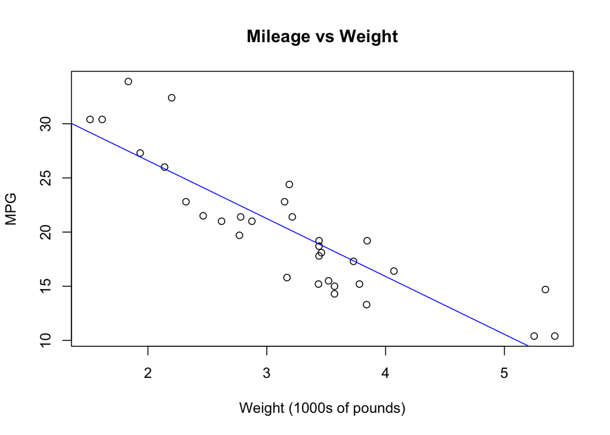

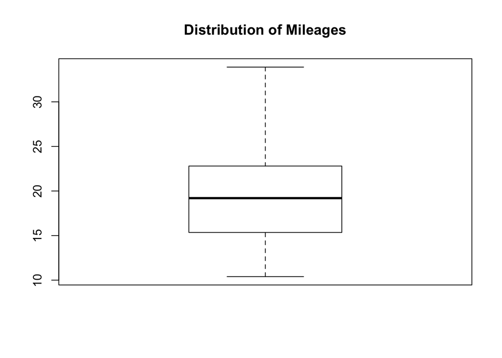